# Real Time Annotation

2019-06-09

#### Package

peakPantheR 0.99.2

**Package**: *peakPantheR*  
**Authors**: Arnaud Wolfer

# 1 Introduction

The `peakPantheR` package is designed for the detection, integration and reporting of pre-defined features in MS files (*e.g. compounds, fragments, adducts, …*).

The **Real Time Annotation** is set to detect and integrate **multiple** compounds in **one** file at a time. It therefore can be deployed on a LC-MS instrument to integrate a set of pre-defined features (*e.g. spiked standards*) as soon as the acquisition of a sample is completed.

Using the *faahKO* raw MS dataset as an example, this vignette will:

- Detail the **Real Time Annotation** concept
- Apply the **Real Time Annotation** to a subset of pre-defined features in the *faahKO* dataset

## 1.1 Abbreviations

- **ROI**: *Regions Of Interest*
  - reference *RT* / *m/z* windows in which to search for a feature
- **uROI**: *updated Regions Of Interest*
  - modifed ROI adapted to the current dataset which override the reference ROI
- **FIR**: *Fallback Integration Regions*
  - *RT* / *m/z* window to integrate if no peak is found
- **TIC**: *Total Ion Chromatogram*
  - the intensities summed across all masses for each scan
- **EIC**: *Extracted Ion Chromatogram*
  - the intensities summed over a mass range, for each scan

# 2 Real Time Annotation Concept

Real time compound integration is set to process **multiple** compounds in **one** file at a time.

To acheive this, `peakPantheR` will:

- load a list of expected *RT* / *m/z* regions of interest (**ROI**)
- detect features in each ROI and keep the highest intensity one
- determine peak statistics for each feature
- return:
  - TIC
  - a table with all detected compounds for that file (*row: compound, col: statistic*)
  - EIC for each ROI
  - sample acquisition date-time from the mzML metadata (*if available*)
  - save EIC plots to disk

# 3 Real Time Annotation Example

In the following example we will target two pre-defined features in a single raw MS spectra file from the *faahKO* package. For more details on the installation and input data employed, please consult the Getting Started with peakPantheR vignette.

## 3.1 Input Data

The path to a MS file from the *faahKO* is located and used as input spectra:

```r
library(faahKO)
## file paths
input_spectraPath  <- c(system.file('cdf/KO/ko15.CDF', package = "faahKO"))
input_spectraPath
```

```
#> [1] "C:/R/R-3.6.1/library/faahKO/cdf/KO/ko15.CDF"
```

Two targeted features (*e.g. compounds, fragments, adducts, …*) are defined and stored in a table with as columns:

- `cpdID` (numeric)
- `cpdName` (character)
- `rtMin` (sec)
- `rtMax` (sec)
- `rt` (sec, optional / `NA`)
- `mzMin` (m/z)
- `mzMax` (m/z)
- `mz` (m/z, optional / `NA`)

```r
# targetFeatTable
input_targetFeatTable <- data.frame(matrix(vector(), 2, 8, dimnames=list(c(),
                        c("cpdID", "cpdName", "rtMin", "rt", "rtMax", "mzMin",
                        "mz", "mzMax"))), stringsAsFactors=FALSE)
input_targetFeatTable[1,] <- c("ID-1", "Cpd 1", 3310., 3344.888, 3390.,
                                522.194778, 522.2, 522.205222)
input_targetFeatTable[2,] <- c("ID-2", "Cpd 2", 3280., 3385.577, 3440.,
                                496.195038, 496.2, 496.204962)
input_targetFeatTable[,c(3:8)] <- sapply(input_targetFeatTable[,c(3:8)],
                                            as.numeric)
```

| cpdID | cpdName | rtMin | rt | rtMax | mzMin | mz | mzMax |
| --- | --- | --- | --- | --- | --- | --- | --- |
| ID-1 | Cpd 1 | 3310 | 3344.888 | 3390 | 522.194778 | 522.2 | 522.205222 |
| ID-2 | Cpd 2 | 3280 | 3385.577 | 3440 | 496.195038 | 496.2 | 496.204962 |

## 3.2 Run Single File Annotation

`peakPantheR_singleFileSearch()` takes as input a `singleSpectraDataPath` pointing to the file to process and `targetFeatTable` defining the features to integrate. The resulting annotation contains all the fitting and integration properties:

```r
library(peakPantheR)
annotation <- peakPantheR_singleFileSearch(
                                    singleSpectraDataPath = input_spectraPath,
                                    targetFeatTable = input_targetFeatTable,
                                    peakStatistic = TRUE,
                                    verbose = TRUE)
```

```
#> Polarity can not be extracted from netCDF files, please set manually the polarity with the 'polarity' method.
#> Reading data from 2 windows
#> Data read in: 1.2 secs
#> Warning: rtMin/rtMax outside of ROI; datapoints cannot be used for mzMin/mzMax calculation, approximate mz and returning ROI$mzMin and ROI$mzMax for ROI #1
#> Found 2/2 features in 0.03 secs
#> Peak statistics done in: 0 secs
#> Feature search done in: 1.77 secs
```

```r
annotation$TIC
```

```
#> [1] 2410533091
```

```r
## acquisition time cannot be extracted from NetCDF files
annotation$acquTime
```

```
#> [1] NA
```

```r
annotation$peakTable
```

Table continues below

| found | rtMin | rt | rtMax | mzMin | mz | mzMax |
| --- | --- | --- | --- | --- | --- | --- |
| TRUE | 3309.759 | 3346.828 | 3385.41 | 522.1948 | 522.2 | 522.2052 |
| TRUE | 3345.377 | 3386.529 | 3428.279 | 496.2 | 496.2 | 496.2 |

Table continues below

| peakArea | maxIntMeasured | maxIntPredicted | cpdID | cpdName | is_filled |
| --- | --- | --- | --- | --- | --- |
| 26133727 | 889280 | 901015.8 | ID-1 | Cpd 1 | FALSE |
| 35472141 | 1128960 | 1113577 | ID-2 | Cpd 2 | FALSE |

| ppm_error | rt_dev_sec | tailingFactor | asymmetryFactor |
| --- | --- | --- | --- |
| 0.02337616 | 1.939759 | 1.015357 | 1.026824 |
| 0.02460103 | 0.9518072 | 1.005378 | 1.009318 |

```r
annotation$curveFit
```

```
#> [[1]]
#> $amplitude
#> [1] 162404.8
#>
#> $center
#> [1] 3341.888
#>
#> $sigma
#> [1] 0.07878613
#>
#> $gamma
#> [1] 0.00183361
#>
#> $fitStatus
#> [1] 2
#>
#> $curveModel
#> [1] "skewedGaussian"
#>
#> attr(,"class")
#> [1] "peakPantheR_curveFit"
#>
#> [[2]]
#> $amplitude
#> [1] 199249.1
#>
#> $center
#> [1] 3382.577
#>
#> $sigma
#> [1] 0.07490442
#>
#> $gamma
#> [1] 0.00114719
#>
#> $fitStatus
#> [1] 2
#>
#> $curveModel
#> [1] "skewedGaussian"
#>
#> attr(,"class")
#> [1] "peakPantheR_curveFit"
```

```r
annotation$ROIsDataPoint
```

```
#> [[1]]
#>          rt    mz    int
#> 1  3315.154 522.2   2187
#> 2  3316.719 522.2   3534
#> 3  3318.284 522.2   6338
#> 4  3319.849 522.2  11718
#> 5  3321.414 522.2  21744
#> 6  3322.979 522.2  37872
#> 7  3324.544 522.2  62424
#> 8  3326.109 522.2  98408
#> 9  3327.673 522.2 152896
#> 10 3329.238 522.2 225984
#> 11 3330.803 522.2 308672
#> 12 3332.368 522.2 399360
#> 13 3333.933 522.2 504000
```

[output cut: 135 more lines]

`peakPantheR_singleFileSearch()` takes multiple parameters that can alter the file annotation:

- `peakStatistic` if `TRUE` calculates additional peak statistics: *‘ppm_error’*, *‘rt_dev_sec’*, *‘tailing factor’* and *‘asymmetry factor’*
- `plotEICsPath` if not `NA` will save a `.png` of all ROI EICs at the path provided (expects `'filepath/filename.png'` for example). If `NA` no plot is saved
- `getAcquTime` if `TRUE` the sample acquisition date-time is extracted from the `mzML` metadata. Acquisition time cannot be extracted from other file formats. The additional file access will impact run time
- `FIR` if not `NULL`, defines the Fallback Integration Regions (**FIR**) to integrate when a feature is not found.
- `verbose` if `TRUE` messages calculation progress, time taken and number of features found (*total and matched to targets*)
- `...` passes arguments to `findTargetFeatures` to alter peak-picking parameters (e.g. the curveModel, the sampling or fitting parameters)

The summary plot generated by `plotEICsPath`, corresponding to the EICs of each integrated regions of interest is as follow:

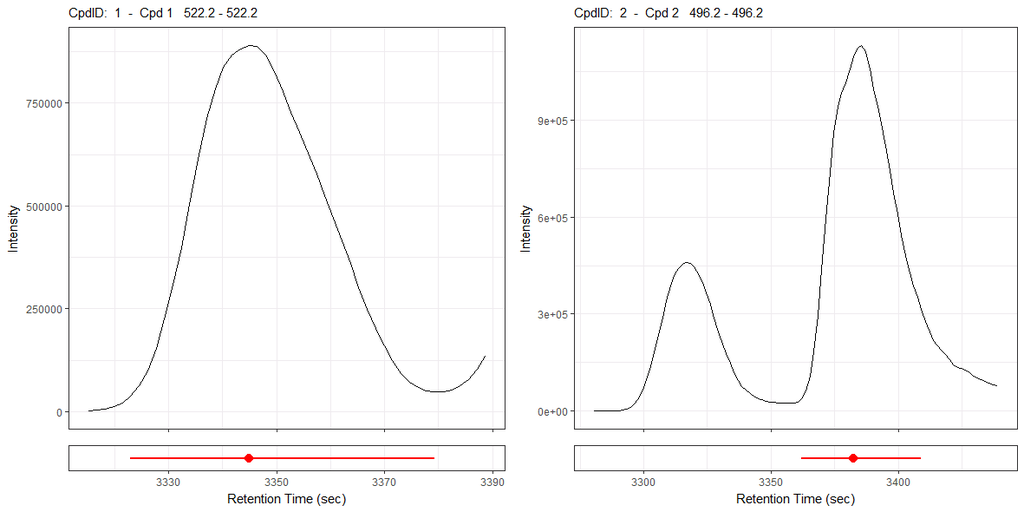

> EICs plot: Each panel correspond to a targeted feature, with the EIC extracted on the `mzMin`, `mzMax` range found. The red dot marks the RT peak apex, and the red line highlights the RT peakwidth range found (`rtMin`, `rtMax`)

# 4 See Also

- Getting Started with peakPantheR
- Parallel Annotation